# Regression and model validation (week 2)

Academic performance of students depends on many factors, which may be difficult to measure and model accurately. The grade that a student gets may be attributable to qualities of each student, e.g. motivation and previous knowledge, but the exact relationship between these is not directly measurable. Linear regression is one of the simplest ways to quantify the relationship $f$ between predictor variables $X$ and a response variable $Y$ using a linear model $\hat Y = \hat f(X)$ [@islr]. By fitting a model to a data set, we can determine the prediction $\hat Y$ by finding an estimate for $\hat f$. If we have the appropriate data set available, it should be possible to roughly predict how well a student performs using a model.

A data set on student learning was created for regression analysis. This data set is based on student learning data[^1] collected in 2014-2015, which describes student learning attitudes and outcomes. The data includes scores from surveys answered by the students, which are used to construct variables that describe different aspects of learning.

An R script was created in [`data/create_learning2014.R`](https://github.com/Roninkoi/IODS-project/blob/master/data/create_learning2014.R) to generate the data set. The raw data contains 183 rows and 60 variables (described in more detail in the code). We include student gender, age and exam points from the raw data in our data set. Additionally, we create variables based on the description in the metadata[^2]. The data contains a number of questions $Q$ on different aspects of learning, which are classified into groups: deep learning $Q_\text{D}$, surface learning $Q_\text{SU}$ and strategic learning $Q_\text{ST}$. Scores for each group are calculated by simply taking the mean over each set of questions: $\text{D} = \overline Q_\text{D}, \ \text{SU} = \overline Q_\text{SU}, \ \text{ST} = \overline Q_\text{ST}.$ This is done similarly for questions on attitude towards statistics, which we also include in our data set. Now our data set consists of the 7 variables `gender`, `age`, `attitude`, `deep`, `stra`, `surf` and `points`. Finally, we filter the data such that it only contains students whose exam points are larger than 0, which leaves us with 166 students The finalized data set is written to `data/learning2014.csv`.

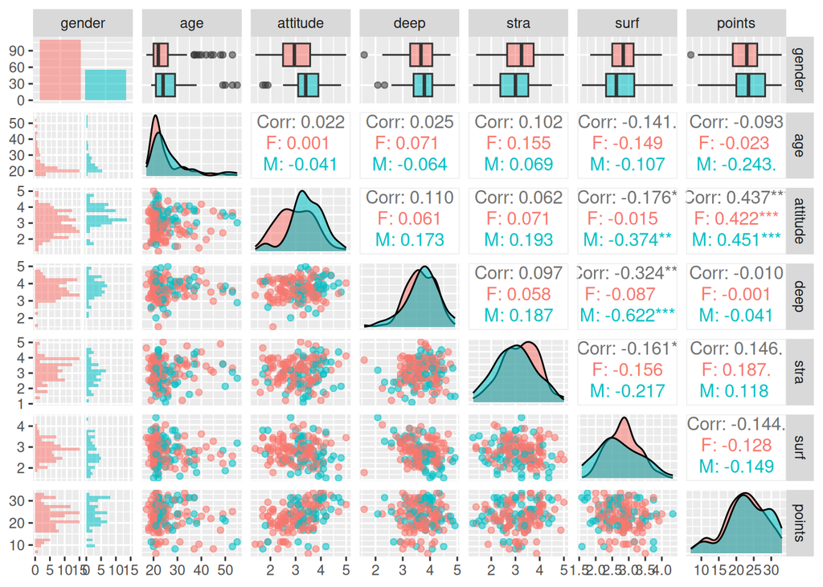

Scatter matrix of the learning2014 data set.

```r
# load data set
learning14 <- read_csv("./data/learning2014.csv")

# plot scatter matrix of variables
sm <- ggpairs(learning14, mapping = aes(colour=gender, alpha=0.7),
              lower = list(combo = wrap("facethist", bins = 20)))
sm
```

```r
# get summaries for different variables
age_summary <- summary(learning14$age)
attitude_summary <- summary(learning14$attitude)
deep_summary <- summary(learning14$deep)
surf_summary <- summary(learning14$surf)
stra_summary <- summary(learning14$stra)
points_summary <- summary(learning14$points)

# calculate number of students
n_students <- nrow(learning14)
n_men <- nrow(filter(learning14, gender == "M"))
n_women <- nrow(filter(learning14, gender == "F"))

kable(data.frame("Age"=c(age_summary[1], age_summary[3],
                         age_summary[4], age_summary[6]),
                 "Attitude"=c(attitude_summary[1], attitude_summary[3],
                              attitude_summary[4], attitude_summary[6]),
                 "Deep"=c(deep_summary[1], deep_summary[3],
                          deep_summary[4], deep_summary[6]),
                 "Surface"=c(surf_summary[1], surf_summary[3],
                             surf_summary[4], surf_summary[6]),
                 "Strategic"=c(stra_summary[1], stra_summary[3],
                               stra_summary[4], stra_summary[6]),
                 "Points"=c(points_summary[1], points_summary[3],
                            points_summary[4], points_summary[6])),
                 caption = sprintf("Summary of different variables for %i students (%i men, %i women).",
                                   n_students, n_men, n_women))
```

Summary of different variables for 166 students (56 men, 110 women).

|  | Age | Attitude | Deep | Surface | Strategic | Points |
| --- | --- | --- | --- | --- | --- | --- |
| Min. | 17.00000 | 1.400000 | 1.583333 | 1.583333 | 1.250000 | 7.00000 |
| Median | 22.00000 | 3.200000 | 3.666667 | 2.833333 | 3.187500 | 23.00000 |
| Mean | 25.51205 | 3.142771 | 3.679719 | 2.787149 | 3.121235 | 22.71687 |
| Max. | 55.00000 | 5.000000 | 4.916667 | 4.333333 | 5.000000 | 33.00000 |

We want to fit a linear model $\hat f(x_1, x_2, x_3) = \beta_0 + \beta_1 x_1 + \beta_2 x_2 + \beta_3 x_3$ to the `learning2014` data set with 3 variables. To choose these variables, we first start by fitting all 7 of them. Fitting the linear model is done by using the `lm()` function. A summary of the fit is generated to get the coefficient values, p-values and $R^2$. The variable with the largest p-value is removed from the model, and the model is fitted again. We continue this process of elimination until only 3 variables are left: `age`, `attitude` and `stra`. The model with all variables “All” and the model with 3 variables “Linear” are shown in table @ref(tab:fe) with their coefficients, p-values and $R^2$. We can see that the 3 variable model has lower p-values for `age` and `attitude`.

The p-values reported for coefficients are calculated using the $t$-test. We want to minimize the p-values for the coefficients of our fit in order to establish statistical significance. For our model’s coefficients to be statistically significant, we would typically like the $p$-value to be less than $5%$. Similarly, we want to maximize $R^2$, which is a measure of how good our model is at predicting the response based on the predictor variables (goodness of fit). It is defined using the errors of the fit as $R^2 = 1 - SS_\text{res} / SS_\text{total}$, where $SS_\text{res}$ is the residual sum of squares and $SS_\text{total}$ is the total sum of squares. By decreasing $SS_\text{res}$, we improve the fit and move $R^2$ closer to 1.

The linear model predicts the exam points using the equation $\hat f = 10.90 - 0.09 \ \text{age} + 3.48 \ \text{attitude} + 1.00 \ \text{stra}$. The variable `attitude` is the most significant, followed by `stra`, accounting for the majority of the points. This suggests that positive attitudes towards the subject and strategic skills (organization, time management, …) play a significant factor in positive learning outcomes, which is an expected association. Age correlates slightly negatively with points, suggesting that younger people are more likely to earn higher scores. It could be that older people have less time to devote to studying, but other factors may also contribute to this.

Only the `attitude` parameter in the linear model has a p-value of less 5%, while `strategy` is fairly close at 6% and `age` at 10%. The $R^2$ score for the linear model 0.218, so the model predicts about 22% of the score based on the chosen variables. The rest can’t be explained using the model, so they are due to external factors not accounted for by the model.

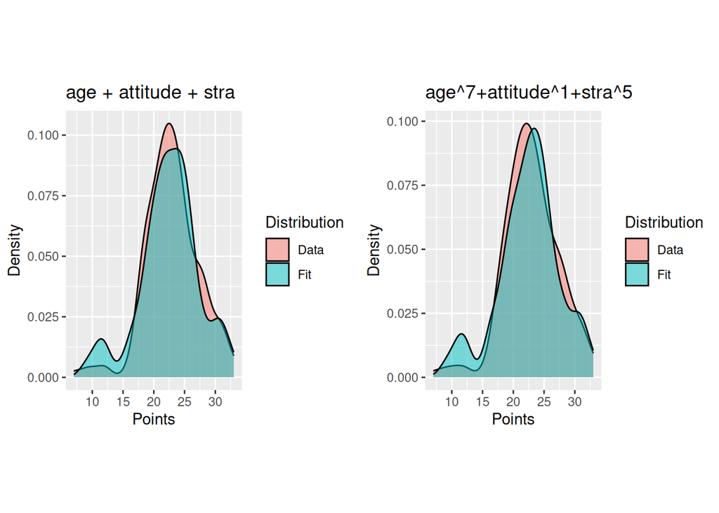

```r
# plot histogram of points for data and fit
fit_hist <- function (data, fit, title) {
  points <- data.frame(Points=c(data$points, predict(fit)),
                     Distribution=c("Data", "Fit"))

  ggplot(points, aes(Points, fill = Distribution)) +
    geom_density(alpha = 0.5) + ylab("Density") + ggtitle(title)
}

# first fit full 7 variable linear model and remove variables based on p-value
fit_full <- lm(points ~ ., data = learning14)
fit_full_summary <- summary(fit_full)

# linear model with 3 most significant variables: age, attitude, stra
fit_lin <- lm(points ~ age + attitude + stra, data = learning14)
fit_lin_summary <- summary(fit_lin)
hist1 <- fit_hist(learning14, fit_lin, title = "age + attitude + stra")

# try to find better model by fitting x^p with varying p
max_r2 <- 0
max_ijk <- c(0, 0, 0)
fit_best <- fit_lin
pn <- 10
for (i in 1:pn) {
  for (j in 1:pn) {
    for (k in 1:pn) {
      # fit model with 3 parameters and varying powers
      fit_ijk <- lm(points ~ I(age^i) + I(attitude^j) + I(stra^k),
                    data = learning14)
      fit_summary <- summary(fit_ijk)

      # is p-value low enough for all parameters?
      good_p <- !any(array(summary(fit_ijk)$coefficients[,4]) > 0.05)

      # if r2 better than best found so far, accept this fit
      if (fit_summary$r.squared > max_r2 && good_p) {
        max_r2 <- fit_summary$r.squared
        max_ijk <- c(i, j, k)
        fit_best <- fit_ijk
      }
    }
  }
}

fit_best_summary <- summary(fit_best)
message("best fit: (", max_ijk[1], ", ", max_ijk[2], ", ", max_ijk[3],
        "), R2: ", max_r2)

hist2 <- fit_hist(learning14, fit_best,
                  sprintf("age^%i+attitude^%i+stra^%i",
                          max_ijk[1], max_ijk[2], max_ijk[3]))

grid.arrange(hist1, hist2, ncol=2, respect=T)
```

```r
kable(data.frame("Fit"=c("Intercept", "Intercept p-value",
                         "Age", "Age p-value",
                         "Attitude", "Attitude p-value",
                         "Strategy", "Strategy p-value", "R^2"),
                 "All"=c(fit_full_summary$coefficients[1,1],
                         fit_full_summary$coefficients[1,4],
                         fit_full_summary$coefficients[2,1],
                         fit_full_summary$coefficients[2,4],
                         fit_full_summary$coefficients[3,1],
                         fit_full_summary$coefficients[3,4],
                         fit_full_summary$coefficients[4,1],
                         fit_full_summary$coefficients[4,4],
                         fit_full_summary$r.squared),
                 "Linear"=c(fit_lin_summary$coefficients[1,1],
                            fit_lin_summary$coefficients[1,4],
                            fit_lin_summary$coefficients[2,1],
                            fit_lin_summary$coefficients[2,4],
                            fit_lin_summary$coefficients[3,1],
                            fit_lin_summary$coefficients[3,4],
                            fit_lin_summary$coefficients[4,1],
                            fit_lin_summary$coefficients[4,4],
                            fit_lin_summary$r.squared),
                 "Best"=c(fit_best_summary$coefficients[1,1],
                          fit_best_summary$coefficients[1,4],
                          fit_best_summary$coefficients[2,1],
                          fit_best_summary$coefficients[2,4],
                          fit_best_summary$coefficients[3,1],
                          fit_best_summary$coefficients[3,4],
                          fit_best_summary$coefficients[4,1],
                          fit_best_summary$coefficients[4,4],
                          fit_best_summary$r.squared)),
                 caption = "Summary of different fits.")
```

Summary of different fits.

| Fit | All | Linear | Best |
| --- | --- | --- | --- |
| Intercept | 18.3024647 | 10.8954281 | 11.3406608 |
| Intercept p-value | 0.0006441 | 0.0000617 | 0.0000000 |
| Age | -0.0585807 | -0.0882187 | 0.0000000 |
| Age p-value | 0.9498454 | 0.0980538 | 0.0016872 |
| Attitude | -0.0960679 | 3.4807679 | 3.4615196 |
| Attitude p-value | 0.0769288 | 0.0000000 | 0.0000000 |
| Strategy | 3.4429973 | 1.0037124 | 0.0017661 |
| Strategy p-value | 0.0000000 | 0.0621222 | 0.0212518 |
| R^2 | 0.2311510 | 0.2181720 | 0.2596390 |

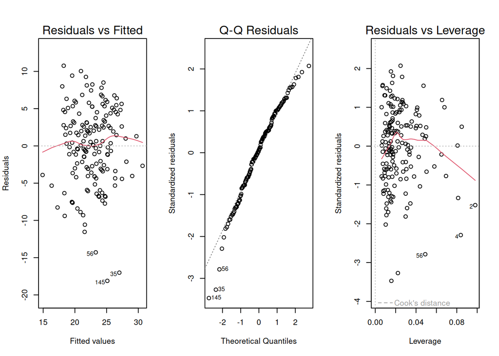

Diagnostic plots for linear model.

```r
par(mfrow=c(1, 3))
plot(fit_lin, which=c(1, 2, 5))
```

[^1]: http://www.helsinki.fi/~kvehkala/JYTmooc/JYTOPKYS3-data.txt
[^2]: http://www.helsinki.fi/~kvehkala/JYTmooc/JYTOPKYS2-meta.txt